# 数学建模

### 模型知识点

### 编程基础-seaborn(2)

**Wang Haihua**

🚅 🚋😜 🚑 🚔

# Seaborn-2

# 在多张图片中展示数据

正如之前`relplot()`中提到的，如果我们希望绘制多张分类的图像，只需要通过设定`row`和`col`参数即可。

```python
import numpy as np
import pandas as pd
import matplotlib.pyplot as plt
%matplotlib inline
import seaborn as sns  # 导入 seaborn 并且命名为sns
sns.set(style="darkgrid") # 设置绘图格式为darkgrid
tips = sns.load_dataset('tips')
tips.head()
```

|  | total_bill | tip | sex | smoker | day | time | size |
| --- | --- | --- | --- | --- | --- | --- | --- |
| 0 | 16.99 | 1.01 | Female | No | Sun | Dinner | 2 |
| 1 | 10.34 | 1.66 | Male | No | Sun | Dinner | 3 |
| 2 | 21.01 | 3.50 | Male | No | Sun | Dinner | 3 |
| 3 | 23.68 | 3.31 | Male | No | Sun | Dinner | 2 |
| 4 | 24.59 | 3.61 | Female | No | Sun | Dinner | 4 |

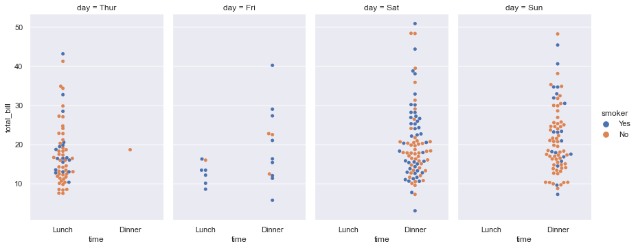

```python
sns.catplot(x="time", y="total_bill", hue="smoker",
            col="day", aspect=.6,
            kind="swarm", data=tips);
```

# 绘制数据分布

当我们遇到一个新的数据集的时候，往往我们首先要搞清楚的就是其中每一个变量的分布。本节我们将会给大家介绍seaborn中一些用于可视化数据分布的函数。

首先我们导入`numpy`,`pandas`,`seaborn`,`pyplot`和`stats`。

```python
import numpy as np
import pandas as pd
import seaborn as sns
import matplotlib.pyplot as plt
from scipy import stats
```

```python
sns.set(color_codes=True)
```

## 绘制单变量分布

在seaborn中，绘制单变量分布的最简单的函数是`displot()`,该函数默认返回一张频率分布直方图以及其对应的核密度估计曲线（KDE）。

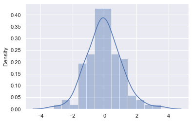

```python
x = np.random.normal(size =100)
sns.distplot(x);
```

### 频率分布直方图

seaborn中的频率分布直方图`displot()`和matplotlib中的`hist()`非常相似。不过，seaborn给出了更为高层次的调用方法，我们可以通过参数`kde`和`rug`控制直方图中kde估计和数据点标记的展示与否。

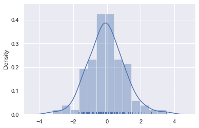

```python
sns.distplot(x, kde=True, rug=True);
```

当绘制直方图的时候，我们经常会调整的一个参数是直方的个数，控制直方个数的参数是`bins`,如果不认为指定`bins`的取值，seaborn会根据自己的算法得到一个较为合理的直方个数，但是通过人为调整直方个数，我们往往能发现新的规律。

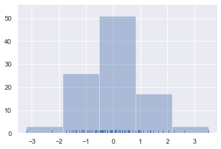

```python
sns.distplot(x, bins=5, kde=False, rug=True);
```

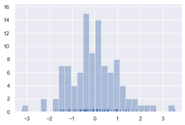

```python
sns.distplot(x, bins=25, kde=False, rug=True);
```

### 核密度估计Kernel density estimation

核密度估计是一种分布的平滑（smooth）方法，所谓核密度估计，就是采用平滑的峰值函数(“核”)来拟合观察到的数据点，从而对真实的概率分布曲线进行模拟。

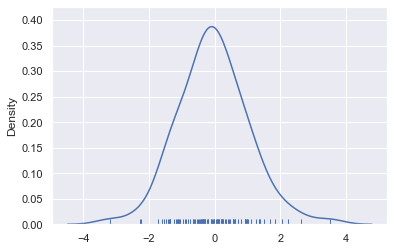

```python
sns.distplot(x, hist=False, rug=True,kde = True);
```

那么，我们是符合得到这样一条曲线的呢？ 实际上，我们将每一个数据点用一个以其为中心的高斯分布曲线代替，然后将这些高斯分布曲线叠加得到的。

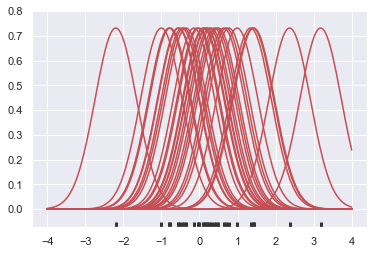

```python
x = np.random.normal(0, 1, size=30)   # 生成中心在0，scale为1，30维的正态分布数据
bandwidth = 1.06 * x.std() * x.size ** (-1 / 5.) # 确定带宽
support = np.linspace(-4, 4, 200)
kernels = []
for x_i in x:
    kernel = stats.norm(x_i, bandwidth).pdf(support)
    kernels.append(kernel)
    plt.plot(support, kernel, color="r")
sns.rugplot(x, color=".2", linewidth=3);
```

将每一个数据转化为以其为中心的正态分布曲线以后，将其叠加，然后归一化，即可得到最终的KDE曲线。

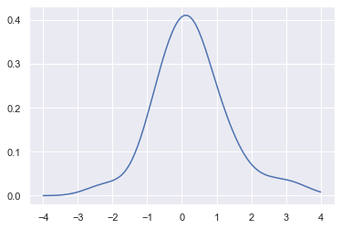

```python
from scipy.integrate import trapz
density = np.sum(kernels, axis=0)
density /= trapz(density, support) # 使用梯形积分计算曲线下面积，然后归一化
plt.plot(support, density);
```

我们可以通过观察，发现，使用seaborn中的`kdeplot()`我们会得到同样的曲线，或者使用`distplot(kde = True)`也有同样的效果。

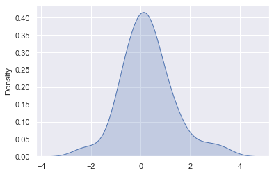

```python
sns.kdeplot(x, shade=True);
```

除了核函数，另一个影响KDE的参数是带宽(h)。带宽反映了KDE曲线整体的平坦程度，也即观察到的数据点在KDE曲线形成过程中所占的比重 — 带宽越大，观察到的数据点在最终形成的曲线形状中所占比重越小，KDE整体曲线就越平坦；带宽越小，观察到的数据点在最终形成的曲线形状中所占比重越大，KDE整体曲线就越陡峭。

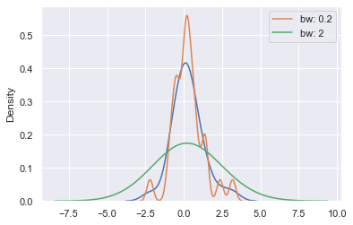

```python
sns.kdeplot(x)
sns.kdeplot(x, bw=.2, label="bw: 0.2")
sns.kdeplot(x, bw=2, label="bw: 2")
plt.legend();
```

通过观察以上的图像我们可以发现，由于高斯分布的引入，我们往往会扩大了变量的取值范围，我们可以通过`cut`参数控制最终图像距离最小值和最大值的距离。需要注意的是，`cut`参数仅仅是改变了图像的展示方法，对kde的计算过程没有影响。

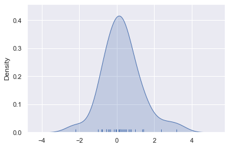

```python
sns.kdeplot(x, shade=True, cut=4)
sns.rugplot(x);
```

### 参数分布的拟合

我们也可以使用`displot()`拟合参数分布，并且将拟合结果与实际数据的分布做对比。

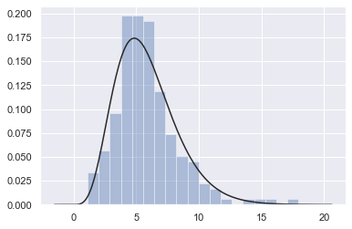

```python
x = np.random.gamma(6, size=200)
sns.distplot(x, kde=False, fit=stats.gamma); # 是用gamma分布拟合，并可视化
```

## 绘制两变量之间的联合分布

有的时候，我们在数据分析的时候，也会关系两个变量之间的联合概率分布关系。seaborn中给我们提供了一个非常方便的`jointplot()`函数可以实现该功能。

```python
mean = [0, 1]
cov = [(1, .5), (.5, 1)]
data = np.random.multivariate_normal(mean, cov, 200)
df = pd.DataFrame(data, columns=["x", "y"])
```

```python
df.head()
```

|  | x | y |
| --- | --- | --- |
| 0 | -0.148139 | -0.080967 |
| 1 | 0.099926 | 2.140157 |
| 2 | 0.690984 | 1.527269 |
| 3 | -0.996052 | -0.467213 |
| 4 | -1.222380 | -0.651693 |

### 散点图

我们最熟悉的绘制联合分布的方法莫过于散点图了。`jointplot()`会返回一张散点图（联合分布），并在上方和右侧展示两个变量各自的单变量分布。

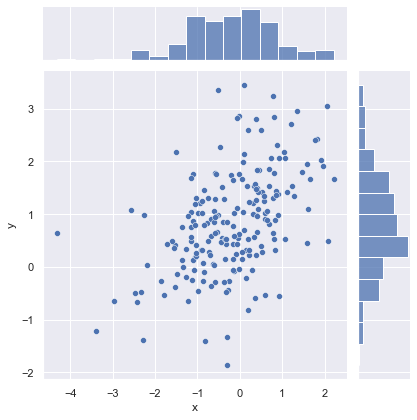

```python
sns.jointplot(x="x", y="y", data=df);
```

### Hexbin plots

与一维柱状图对应的二维图像称之为Hexbin plots，该图像帮助我们统计位于每一个六边形区域的数据的个数，然后用颜色加以表示，这种方法尤其对于大规模的数据更为适用。

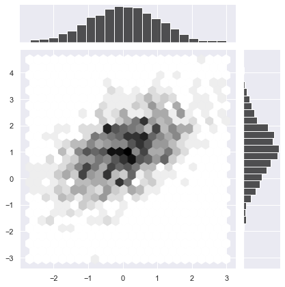

```python
x, y = np.random.multivariate_normal(mean, cov, 1000).T
sns.jointplot(x=x, y=y, kind="hex", color="k");
# with sns.axes_style("white"):
#     sns.jointplot(x=x, y=y, kind="hex", color="k");
```

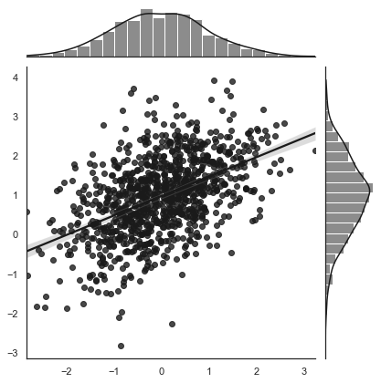

```python
x, y = np.random.multivariate_normal(mean, cov, 1000).T
with sns.axes_style("white"):
    sns.jointplot(x=x, y=y, kind="reg", color="k");
```

### 联合分布的核密度估计

类似于一维情况，我们在二维平面一样可以进行核密度估计。通过设置`kind = 'kde'`，我们就可以得到一个核密度估计的云图，以及两个单变量的核密度估计曲线。

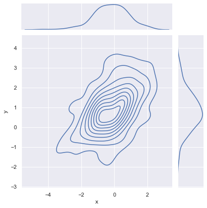

```python
sns.jointplot(x="x", y="y", data=df, kind="kde");
```

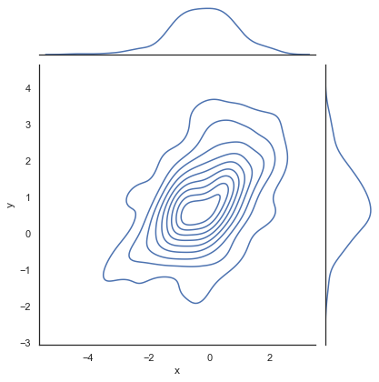

```python
with sns.axes_style("white"):
    sns.jointplot(x="x", y="y", data=df, kind="kde");
```

我们也可以直接使用`kdeplot()`绘制二维平面上的核密度估计。而且，结合面向对象的方法，我们还可以把新的绘图加入到已有的图片上。

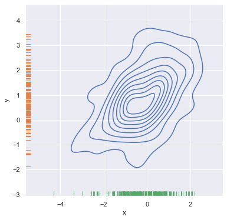

```python
f, ax = plt.subplots(figsize=(6, 6))
sns.kdeplot(df.x, df.y, ax=ax)
sns.rugplot(df.x, color="g", ax=ax)
sns.rugplot(df.y, vertical=True, ax=ax);
```

If you wish to show the bivariate density more continuously, you can simply increase the number of contour levels:

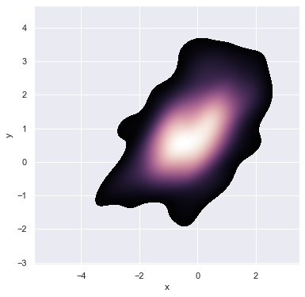

```python
f, ax = plt.subplots(figsize=(6, 6))
cmap = sns.cubehelix_palette(as_cmap=True, dark=0, light=1, reverse=True)
sns.kdeplot(df.x, df.y, cmap=cmap, n_levels=509, shade=True);
```

我们还可以给图片添加新的图层，将数据的散点图绘制在原图上，包括给图片添加坐标轴标签等等。

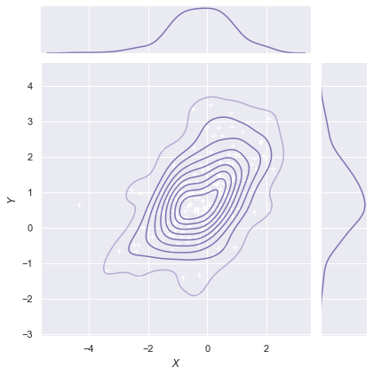

```python
g = sns.jointplot(x="x", y="y", data=df, kind="kde", color="m")
g.plot_joint(plt.scatter, c="w", s=30, linewidth=1, marker="+")
g.ax_joint.collections[0].set_alpha(0.5)
g.set_axis_labels("$X$", "$Y$");
```

# 分组可视化

## 可视化线性关系

许多数据集都包含了众多变量，有的时候我们希望能够将其中的一个或者几个联系起来。上一节我们讲到了seaborn中很多绘制联合分布的方法，比如`jointplot()`，本节我们进一步地，讨论变量之间线性关系的可视化。

需要注意的是，seaborn并不是一个统计学的库，seaborn想要实现的是：通过运用简单的统计工具，尽可能简单而直观地给我们呈现出数据之间相互关系。有的时候，对数据有一个直观的认识，能帮助我们更好地建立模型。

```python
import numpy as np
import seaborn as sns
import matplotlib.pyplot as plt
```

```python
sns.set(color_codes=True)
```

### 绘制线性回归的函数

在seaborn中，有两个函数经常被用于实现线性回归，他们是`lmplot`和`regplot`。接下来我们会介绍这两个函数的异同。

在最简单的情况下，两个函数均会返回一个散点图，并给出$y$关于$x$的线性回归方程以及一个95%的置信区间。

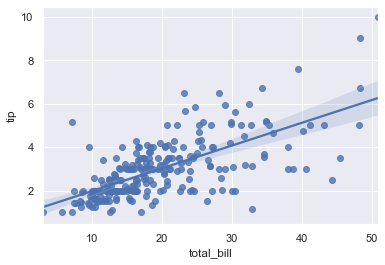

```python
sns.regplot(x="total_bill", y="tip", data=tips);
```

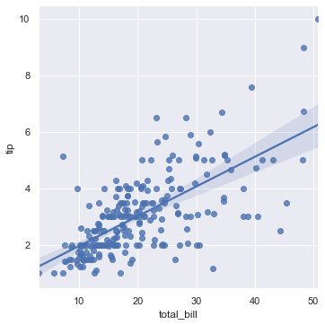

```python
sns.lmplot(x="total_bill", y="tip", data=tips);
```

我们发现，除了图的尺寸，这两个图的内容是完全一致的。

那么，这两个函数有什么不同呢？

- `regplot()`能接受更多种形式的数据，例如numpy arrays, pandas Series, references to variables in a pandas DataFrame，而 `lmplot()`只能接受references to variables in a pandas DataFrame，也就是只能接受“tidy” data
- `regplot()` 仅仅指出 `lmplot()`的一部分参数

我们可以对一个离散变量和一个连续变量绘制线性回归线，不过，可视化结果往往是不尽如人意的。

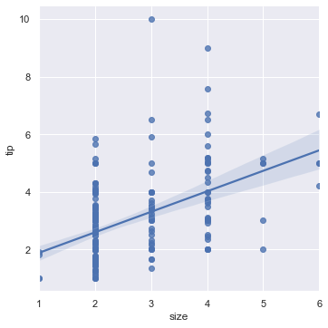

```python
sns.lmplot(x="size", y="tip", data=tips);
```

针对上面这个图像，一个选择是给每一个离散的变量增加一个随机的扰动`jitter`，使得数据的分布更容易观察，请注意，`jitter`参数的存在仅仅是改变了可视化的效果，不会影响线性回归方程。

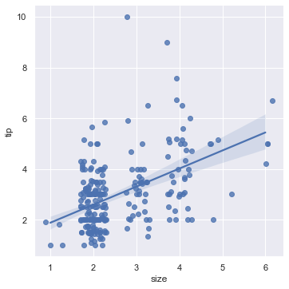

```python
sns.lmplot(x="size", y="tip", data=tips, x_jitter=.3);
```

另一个选择是，我们直接将每一个离散类别中的所有数据统一处理，得到一个综合的趋势以及每个数据点对应的置信区间。

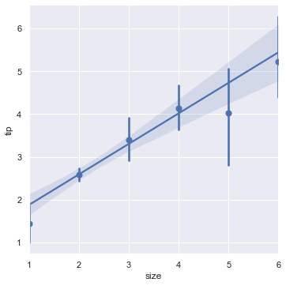

```python
sns.lmplot(x="size", y="tip", data=tips, x_estimator=np.mean);
```